# Extraindo Movimentações com RegEx

José Matheus

26/10/2020

## Extraindo informações de processos de recuperação judicial

Versão 6, lendo dados de movimentação atualizados pelo professor (03/08/20)

#### 1. Gerar um relatório reproduzível em R

#### 2. Explicar brevemente os objetivos da análise

Queremos usar o R para extrair dados de processos de recuperação judicial. A recuperação judicial é um processo onde a empresa em dificuldades financeiras entra na justiça para renegociar as dívidas com seus credores e obter um prazo maior para pagamento. Caso a maioria dos credores não concorde com o pedido da empresa, aí a recuperação judicial é transformada em falência.

Usaremos estes dados para estimar os efeitos de uma possível reforma da Lei de Falências usando um modelo de barganha, conforme parte do abstract do meu projeto de pesquisa:

> “A reforma da Lei de Falências Brasileira de 2005 teve impactos positivos na oferta de crédito (Araujo et al., 2012) e investimento das firmas (Ponticelli e Alencar, 2016). Contudo, atrasos (Sacramone et al., 2017) e baixas taxas de recuperação (Jupetipe et al., 2017) marcam os procedimentos atuais. Dado esse cenário desmotivador, existe uma discussão de reforma em andamento no Brasil. Esta destina-se a, dentre outras coisas, estimular financiamentos para empresas em recuperação judicial e priorizar as reivindicações fiscais em caso de reorganização das firmas. Nosso objetivo é contribuir para tal discussão ao estimar o modelo estrutural de Dou et al. (2019) para fricções em falências. Em particular, trataremos dos efeitos da reforma sobre excesso de liquidação/reorganização, duração dos acordos e taxas de recuperação. Consequentemente, nosso projeto também contribui para a literatura de desenho ótimo de falências e estimação de jogos não cooperativos.”

Para estimar esse modelo, precisamos saber de algumas datas importantes no processo de recuperação judicial:

1. Quando a empresa deu entrada no processo
2. Quando a empresa teve ou a sua recuperação judicial aprovada (homologação do plano) ou recusada, daí a recuperação é convolada em falência
3. Quanto tempo demorou, em média, entre as reuniões de credores para decidir o que fazer com a firma.

Neste trabalho vamos extrair os dados 1) e 2). O dado 3) é um pouco mais complicado de conseguir, pretendo fazer depois.

Por que usar mineração de dados? O principal motivo é tornar os resultados da pesquisa mais reproduzíveis. Se eu coletasse os dados manualmente (olhando cada movimento de cada processo), seria muito custoso para outra pessoa verificar os resultados da minha pesquisa Contudo, se eu faço isso por meio de códigos, basta verificar os códigos ao invés de centenas de processos.

Outros motivo (não menos importante): fazer a análise assim é muito mais divertido.

A principal desvantagem de usar o R neste caso é que alguns dados podem ser classificados erroneamente. Para isso, preciso pensar em mais testes para verificar a consistência deles.

#### 3. Abrir pelo menos um banco de dados externo, ou montar um banco de dados original

Vou montar um banco de dados original a partir dos dados já extraídos da internet fornecidos pelo meu orientador.

Tais dados foram extraídos pelo meu orientador, Dr. Rafael Ferreira, que me enviou para determinar essas datas importantes de cada processo. A base de dados contém as seguintes colunas:

- fullMatch e linkToPdf: são colunas geradas no processo de extração dos dados. Não usaremos aqui.
- date: a data na qual a movimentação (decisão, decreto, ato ordinário, dentre outras) no processo aconteceu
- movimento: qual o tipo de movimento que aconteceu: se foi uma decisão, se foi uma publicação de edital, se foi declarada a falência da empresa, dentre outros
- detalhes: o texto que está na movimentação do caso. É analisando esta coluna que vamos determinar quando aconteceram as principais movimentações.
- id: coluna de identificação usada na extração dos dados. Não usaremos aqui.
- processo: número do processo de recuperação judicial. Cada número de processo é único. Há várias movimentações para cada processo.

```
## [1] 272
```

#### 4. Manipular, transformar e limpar os dados para atender os objetivos

##### Dificuldades

A principal dificuldade é que esses dados não foram feitos para serem usados em pesquisas acadêmicas. Prova disso é que as movimentações dos processos não têm um padrão. Por exemplo, há 491 textos possíveis para classificar a movimentação ocorrida. Isto dificulta sabermos as datas de movimentações importantes dos processos.

Outro exemplo, se filtrarmos para o movimento “Concedida a recuperação judicial”, teremos apenas 38 observações, quando na verdade boa parte dos 272 processos analisados deveria ter um movimento desses.

Diante disso, podemos procurar expressões que facilitem a nossa procura pelas datas-chave dos processos.

##### Método usado no projeto

O método que usei nesse projeto foi:

1. filtrar os casos que já tinham a classificação correta, por exemplo, “Concedida a recuperação judicial”
2. analisar os textos dos casos encontrados procurando expressões que os juízes usassem sempre
   - a maior parte dessa análise foi manual, lendo os processos mesmo
   - tentei tokenizar os textos e até procurar as palavras mais distintas entre as movimentações. Contudo, não achei os resultados disso tão úteis (deixei o código em rascunho, caso queira verificar)
3. busquei as expressões encontradas em 2) e verifiquei se tinham alguma inconsistência óbvia
4. organizei a data de cada evento para os processos nos quais encontrei dados

##### Data de requerimento/ Filing date

A data inicial de cada processo de recuperação inicial será a data de quando a empresa fez o requerimento da recuperação judicial. A nossa proxy para isso é a data da primeira movimentação oficial no caso, usualmente a data de distribuição do processo.

#### Data de deferimento da RJ/Start date

Data quando o juiz aprova a documentação apresentada pela empresa e concede o stay period. Regulada pelo artigo 152 da Lei 11.101/2005. Esse é o começo do período analisado pelo modelo.

##### Datas de finalização do processo de recuperação judicial

Pesquisamos essas datas antes das datas de aprovação/rejeição do plano porque alguns processos de recuperação judicial são convertidos em falência por rejeição do plano de recuperação em assembleia geral de credores. Nestes casos, a data de rejeição do plano é a mesma data da decretação da falência.

Criaremos um banco de dados juntando as informações coletadas até agora.

Checagem dos processos para os quais não conseguimos encontrar datas de finalização usando RegEx.

##### Data de aprovação/rejeição do plano

A outra etapa importante é a data quando o plano de recuperação judicial é aprovado ou rejeitado. Para o plano ser aprovado, 1) ou ele não deve ter sofrido objeção dos credores ou 2 ele pode ter sofrido objeção, mas ter sido aprovado pela maioria dos credores em assembleia geral. Se o plano for rejeitado, a recuperação judicial é transformada em falência (o termo técnico é “convolada em falência”)

No caso da aprovação (homologação) do plano, identifiquei que os juízes usualmente falam “concedo a recuperação judicial” em suas decisões. Fiz um filtro baseado nesse critério. Aprovação, homologação do plano e concessão da recuperação judicial são sinônimos no contexto desse projeto.

Um problema que acontece é que às vezes um documento cita trechos de decisões anteriores. Então se buscarmos “concedo a recuperação judicial”, apareceria mais de uma movimentação para alguns processos. A primeira é a data da aprovação do plano de fato, enquanto a segunda movimentação apenas cita a primeira. A solução para isso foi filtrar apenas as primeiras movimentações encontradas para cada processo.

Essa data marca o final do período analisado pelo modelo usado na minha dissertação.

Juntando os dados de homologação ao nosso banco de dados.

Descartamos casos em que a empresa faliu antes de votar o PRJ. Ou que ela desistiu da PRJ. Assim, sobraram apenas casos nos quais ocorreu a decretação de falência por rejeição do plano. Vamos considerar a data de falência como a data de rejeição do plano, então.

```
## # A tibble: 0 x 15
## # ... with 15 variables: processo <chr>, data_req <date>, data_final <date>,
## #   resultado <chr>, detalhes_final <chr>, detalhes_final_resumo <chr>,
## #   id_linha_final <int>, data_start <date>, detalhes_start <chr>,
## #   detalhes_start_resumo <chr>, id_linha_start <int>, data_hom <date>,
## #   detalhes_hom <chr>, detalhes_hom_resumo <chr>, id_linha_hom <int>
```

```
## # A tibble: 0 x 15
## # ... with 15 variables: processo <chr>, data_req <date>, data_final <date>,
## #   resultado <chr>, detalhes_final <chr>, detalhes_final_resumo <chr>,
## #   id_linha_final <int>, data_start <date>, detalhes_start <chr>,
## #   detalhes_start_resumo <chr>, id_linha_start <int>, data_hom <date>,
## #   detalhes_hom <chr>, detalhes_hom_resumo <chr>, id_linha_hom <int>
```

#### Processos que tiveram objeção

Aqui a busca é para encontrar processos que tiveram objeção. É algo binário. Não precisamos saber QUANDO a objeção ocorreu, precisamos apenas saber SE ocorreu alguma objeção.

Uma Assembleia Geral de Credores(AGC) pode ser convocada após um deles prestar objeção (arts. 55 e 56). Ou então quando o devedor se afastar (art 64), pode convocar AGC para nomear um Comitê de Credores quando decreta a falência da empresa (art. 99), para deliberar sobre alienação de ativos da empresa ainda em RJ (art. 145), quando o adm judicial considerar necessário (art. 22), quando convocada pelo Comitê de Credores (art. 27). O artigo 35 resume os cenários sobre os quais a AGC delibera: aprovação ou rejeição do PRJ, constituição do comitê de credores, pedido de desistência do devedor, nome do gestor judicial quando o devedor for afastado, ou qualquer outra matéria que possa afetar os interesses dos credores.

Assim, para entender os casos nos quais tivemos objeção, vamos procurar as palavras-chave “assembleia geral de credores” e “agc”. Depois filtraremos para todos os casos que ocorreram ANTES da aprovação ou rejeição do plano.

Existem alguns casos em que o juiz fala “se tiver objeção, então convoque assembleia”. Esses casos são mais difíceis de lidar. No entanto, sempre que há assembleia, o juiz deve citar que o plano foi aprovado na sentença em que homologa o plano de recuperação judicial (detalhes_hom). Assim, eu vou manter como objeção somente os casos onde:

```
* A data da primeira citação de "assembleia" ocorre antes da decisão de aprovar ou rejeitar o plano e
* O texto de "assembleia" contém a palavra "convocação", pois isso indica que o juiz realmente convocou agc
  * Caso o texto não tenha convocação, temos que olhar os critérios abaixo:
      * a decisão de aprovar/rejeitar contém as palavras "aprovado" ou "rejeitado", pois o juiz deve levar as deliberações da AGC em consideração.
      * A decisão de aprovar/rejeitar cita artigo 73 inciso iii, que é quando a falência é decretada porque os credores rejeitaram o plano
```

Casos que não têm objeção são casos em que:

```
*a data do movimento citando assembleia ocorre depois da data de homologação
*ou: data_agc < data_hom, mas a decisão de homologação NÂO cita APROV/REJEIT e TAMBÈM contém as palavras "objecao" e "impugnac". Pois sempre que o juiz cita objeção e impugnação na decisão de homologação é porque ele tá falando que não tem. Chequei manualmente isso.
```

```
## # A tibble: 2 x 2
##   tem_obj     n
##     <dbl> <int>
## 1       0    17
## 2       1   192
```

#### Checando se há planos aprovados por cram down

#### Número de meses entre as decisões do juiz

#### 6. Gerar pelo menos uma tabela bem formatada no relatório final

O resultado dos dados encontrados está na tabela abaixo.

O número de casos para os quais não sabemos a data de homologação é 0.

O número de casos para os quais não sabemos a data de finalização do processo é 0.

E o número de casos para os quais não sabemos nem a data de homologação nem a data de finalização do processo é 0.

Estatísticas Descritivas

|  | Meses entre requerimento e final | Meses entre requerimento e deferimento | Meses entre deferimento e homologação | Meses entre homologação e final |
| --- | --- | --- | --- | --- |
|  | Min. : 12.40 | Min. : 0.03333 | Min. : 5.733 | Min. : 0.00 |
|  | 1st Qu.: 32.43 | 1st Qu.: 0.60000 | 1st Qu.:11.400 | 1st Qu.: 11.93 |
|  | Median : 45.27 | Median : 1.16667 | Median :14.033 | Median : 28.20 |
|  | Mean : 48.45 | Mean : 1.78756 | Mean :16.459 | Mean : 30.20 |
|  | 3rd Qu.: 57.83 | 3rd Qu.: 2.13333 | 3rd Qu.:19.467 | 3rd Qu.: 40.67 |
|  | Max. :123.33 | Max. :28.73333 | Max. :67.200 | Max. :106.07 |

```
## # A tibble: 4 x 3
## # Groups:   tem_obj [2]
##   tem_obj resultado   mean_req_hom
##     <dbl> <chr>       <drtn>
## 1       0 liquidated  12.85000 days
## 2       0 reorganized 12.56667 days
## 3       1 liquidated  15.46667 days
## 4       1 reorganized 13.03333 days
```

#### 7. Gerar pelo menos dois gráficos ou mapas bem formatados no relatório final

O primeiro gráfico é a densidade do número de meses entre o requerimento da recuperação judicial e o final do processo. Sim, existem casos que passam mais de 10 anos na corte antes de encerrarem. Na nossa amostra, a maioria dos casos demora até 6 anos para terminar.

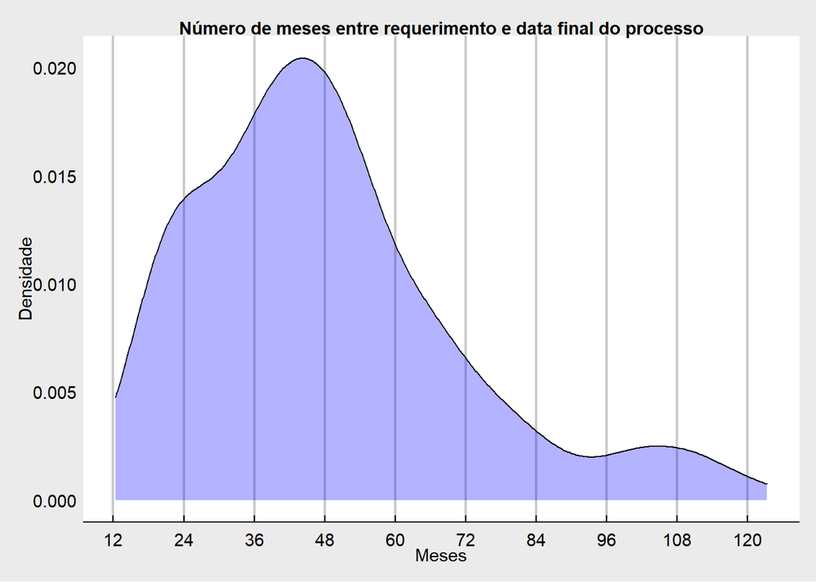

Após o deferimento da recuperação judicial, o juiz suspende todas as cobranças contra a empresa pelo prazo de 180 dias. Neste período espera-se que a empresa apresente um plano de recuperação judicial e consiga apoio de seus credores. Então destacamos o prazo de 6 meses na linha tracejada no gráfico. Percebe-se que a minoria dos casos cai dentro desse prazo “ideal”.

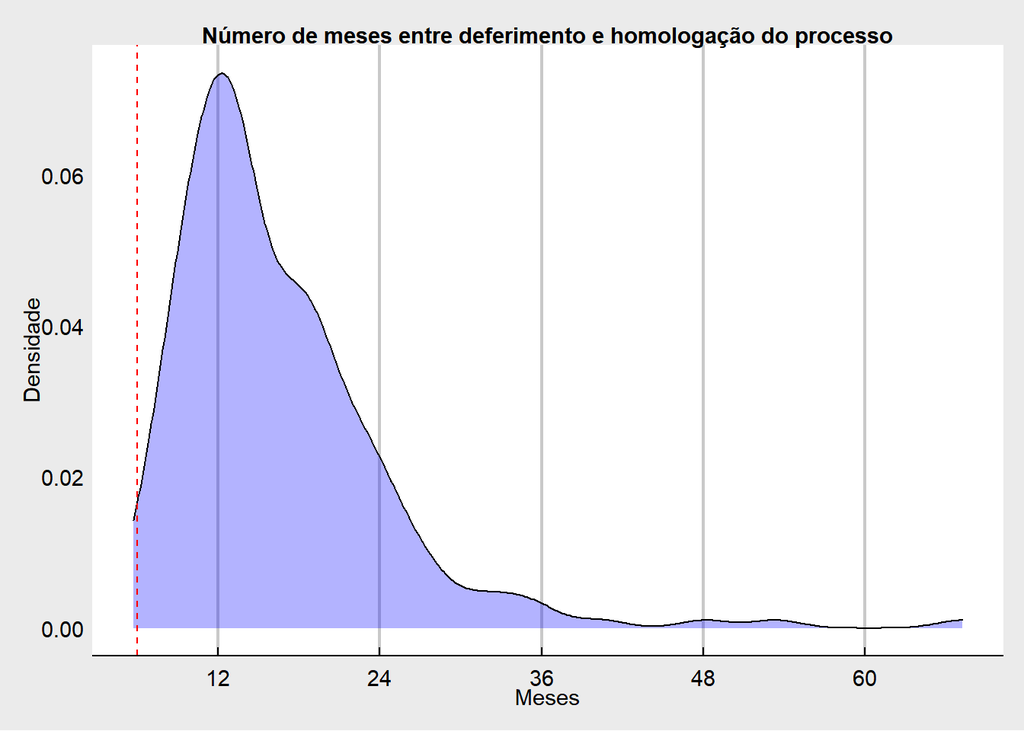

Prazos muitos altos entre deferimento e homologação ou foram porque o processo demorou mesmo ou porque a empresa faliu após ter o plano rejeitado pelos credores. Nos dois casos, tem uma demora.

Após a homologação do plano, a empresa ainda passa um período de pelo menos dois anos sob supervisão judicial. Esse é o período mínimo antes que o juiz encerre o processo considerando a empresa recuperada de fato. Se o processo foi encerrado antes disso é porque a empresa não conseguiu cumprir seu plano de recuperação judicial, logo teve seu processo transformado em uma falência. A linha pontilhada agora destaca esse prazo de 24 meses.

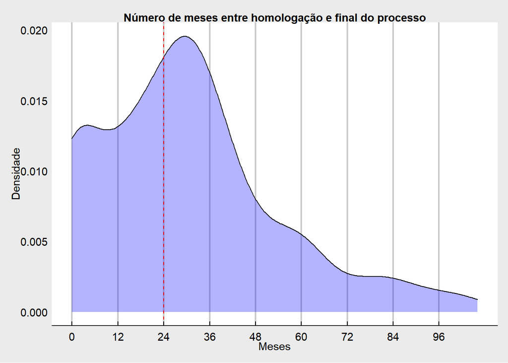

Visualmente, parece que mais de um terço dos casos possui menos de 24 meses entre homologação e finalização. De fato, considerando apenas os casos com número de meses superior a zero, temos um total de 175 casos, dos quais 52 se encerram antes de 24 meses. Isto significa que pelo menos 29.71% dos casos nos quais os credores chegam a aprovar um plano de recuperação são transformados em falência porque a empresa não conseguiu cumprir com o plano.

#### 9. Configurar os parâmetros dos chunks para gerar um relatório limpo e claro

#### 10. Submeter o seu script, e o documento final (HMTL/PDF)

#### 11. Extração de dados